# Análisis estadístico de datos de Microbioma con R

Capítulo 7: Análisis exploratorio de datos de microbiomas

Equipo 4

Andrés Arredondo Cruz (andresabstract@gmail.com)

Adriana Haydé Contreras Peruyero (haydeeperuyero@gmail.com)

David Alberto García Estrada (david.garcia.e@cinvestav.mx)

2022-09-27

# Datos de Ratones y Humanos

## Conjuto de datos de ratón $Vdr^{-/-}$

Los datos del microbioma intestinal murino (Jin et al.2015 se obtuvieron de muestras de heces fecales y cecales. Aquí, se utilizan las muestras fecales.

## Conjuto de datos de fumadores de cigarro

El segundo conjunto de datos es de Charlson et al. ([2010](https://www.ncbi.nlm.nih.gov/pmc/articles/PMC3004851/)) y Chen ([2012](https://cran.r-project.org/web/packages/GUniFrac/index.html)), que incluye estudios sobre el efecto del tabaquismo en el microbioma del tracto respiratorio superior. El conjunto de datos original contiene muestras de microbiomas de garganta y nariz, y de ambos lados del cuerpo. El conjunto de datos utilizado en este capítulo proviene del microbioma de la garganta del lado izquierdo del cuerpo. Contiene 60 sujetos (32 no fumadores y 28 fumadores). El conjunto de datos incluye tres datos: recuento de abundancia, árbol y metadatos. Es adecuado para ilustrar el diagrama de árbol y el análisis de ordenación restringida.

# Análisis exploratorio como resumen gráfico

Podemos dividir los métodos de estudio de la composición de la comunidad de microbiomas en dos componentes principales: - Análisis de diversidades taxonómicas - Análisis multivariante de la composición del microbioma

El análisis multivariado incluye varias técnicas multivariadas, como el agrupamiento y la ordenación (sin restricciones y con restricciones) y las diferencias de prueba de hipótesis entre los grupos.

Usaremos el paquete de “Phyloseq” que es una herramienta bastante importante, almacena, analiza y muestra gráficamente datos complejos filogenéticos. Los datos de entrada usados en este paquete pueden ser OTUs o datos de abundancia de cuentas. Este paquete usa sistemas gráficos y avanzados (ggplot2) para facilitar gráficas de calidad de datos.

En este capítulo se exploran diferentes gráficos usuales: riqueza, barras de abundancia, mapas de calor, redes y árbol filogenético.

## Gráficos de riqueza

Las diversidades alfa estimadas pueden resumirse mediante un gráfico utilizando la función `plot_richness()` del paquete `phyloseq`. Aunque su nombre sugiere trazar “riqueza”, que normalmente se refiere a trazar el número total de especies/taxa/OTUs en una muestra o entorno, en realidad la función no sólo traza la riqueza, sino que también genera cifras de diversidades observadas y otras estimadas.

En primer lugar, debemos cargar los paquetes `phyloseq` y `ggplot2`, y el conjunto de datos de ratones Vdr$-/-$.

```r
#Para instalar el paquete, usamos Bioconductor

#if (!require("BiocManager", quietly = TRUE))
 # install.packages("BiocManager")

#BiocManager::install("phyloseq")
```

```r
# IMPORTANTE
# Ajustamos path de trabajo según tu PC
# Mostramos directorio actual
getwd()
```

```
## [1] "D:/Users/hayde/Documents/R_sites/Equipo4/Chapter7"
```

```r
# Si es necesario, cambiar la ruta donde están los archivos almacenados.
# "." significa el directorio actual.
workingDir <-  "."
setwd(workingDir)
```

```r
# cargamos librerias
library("phyloseq")
library("ggplot2")
library("igraph")
library("vegan")
library("GUniFrac")
library("pbkrtest")
library("BiodiversityR")
library("kableExtra")
```

En la carpeta `data` se encuentra la base de datos a usar `VdrFecalGenusCounts.csv`.

```r
# Mandamos llamar los datos originales
# Fila es el taxón y columna la condición
abund_table=read.csv(paste0(workingDir,"/data/VdrFecalGenusCounts.csv"), row.names=1,check.names=FALSE)
# Generamos la transpuesta, fila la condición, columna el taxón
abund_table<-t(abund_table)
```

El paso crítico cuando se utiliza el paquete phyloseq es construir un objeto `phyloseq-class`. El siguiente código R construye un objeto de clase phyloseq llamado physeq utilizando el comando `phyloseq()`. El objeto de clase phyloseq se construye a partir de sus componentes datos: - Tabla OTU. - Datos muestra. - Tabla de taxonomía. - Árbol filogenético.

Como objeto a nivel de experimento, deben proporcionarse dos o más objetos de datos componentes. El orden de los argumentos no importa.

```r
# Hacemos una tabla que incluye el nombre de las filas y además incluye como dato,
#estos nombres separados por "_"
meta_table <- data.frame(row.names=rownames(abund_table),
                         t(as.data.frame(strsplit(rownames(abund_table),"_"))))
# Hacemos factor la columna "X2" y los que sean 11, 12, 13, 14 y 15 serán "Vdr-/-",
#el resto será "WT"
meta_table$Group <- with(meta_table,ifelse(as.factor(X2) %in%
                                             c(11,12,13,14,15), c("Vdr-/-"), c("WT")))
```

Convertimos los datos al formato `phyloseq`.

```r
# OTUs
OTU <- otu_table(as.matrix(abund_table), taxa_are_rows = FALSE)
# Sample
SAM <- sample_data(meta_table)
# Unimos en un objeto phyloseq
physeq <- merge_phyloseq(phyloseq(OTU),SAM)
physeq
```

```
## phyloseq-class experiment-level object
## otu_table()   OTU Table:         [ 248 taxa and 8 samples ]
## sample_data() Sample Data:       [ 8 samples by 4 sample variables ]
```

Una vez que tenemos nuestro objeto `phyloseq`, podemos usar la función `plot_richness()` para construir graficar las diversidades alpha observadas y estimadas.

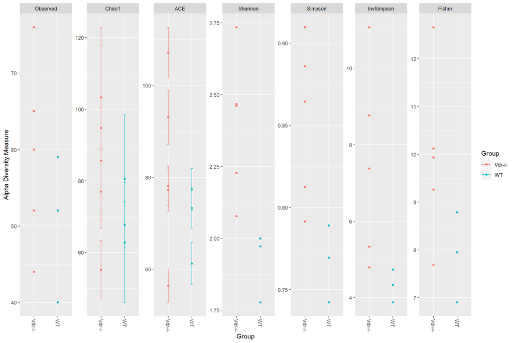

Gráficos de diversidad alpha con Vdr y grupos WT en muestras de heces.

```r
plot_richness(physeq, x = "Group ", color = "Group ")
```

Esta función también nos permite seleccionar solo algunas diversidades. El siguiente es un ejemplo usando solo dos diversidades, la de Chao1 y Shannon.

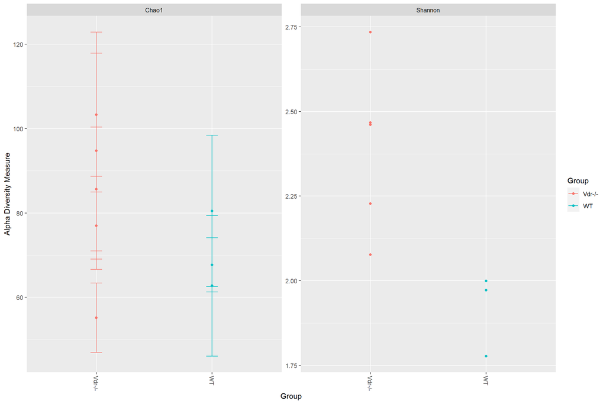

Gráficos de diversidad alpha seleccionando las diversidades de Chao y Shannon.

```r
plot_richness(physeq, measures = c("Chao1", "Shannon"),x = "Group ", color = "Group ")
```

Se requiere el dato de entrada “physeq”, que es de la clase “phyloseq”, o alternativamente, un una tabla OTUs. El argumento opcional “x” es una variable que se asigna al eje horizontal; x puede ser una cadena de caracteres o un vector. El valor por defecto es “samples”, que asignará el nombre de cada muestra a una posición horizontal distinta en el gráfico. En este caso, `x = "Group"` asignará la pertenencia a un grupo al eje x. El argumento color también es opcional. Especificará la variable de muestra que se asignará a diferentes colores. Al igual que el argumento x, puede ser una cadena de caracteres o un vector. En la estimación de la diversidad alfa, el ruido puede recortarse; sin embargo, dado que muchas estimaciones de riqueza e incluso la riqueza “observada” dependen en gran medida del número de individuos. Por lo tanto, si desea obtener resultados significativos, debe utilizar conjuntos de datos sin recortar (McMurdie y Holmes 2013).

## Gráfico de barras de abundancia

El diagrama de barras por defecto, sin ningún parámetro, trazará con cada muestra individualmente en el eje x, y los valores de abundancia en el eje y. Los valores de abundancia para cada OTU/muestra se apilan en el orden de mayor a menor, separados por una fina línea horizontal.

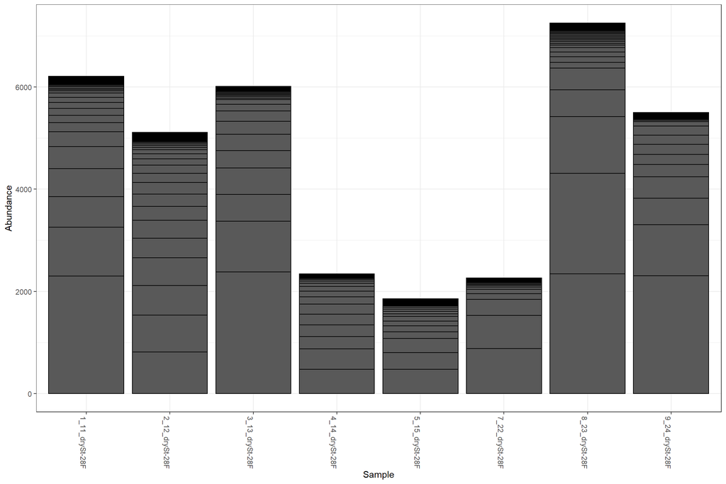

Gráfico de barras de abundancia por defecto.

```r
theme_set(theme_bw())
# Gráfico de barras
plot_bar(physeq)
```

Otros parámetros que se pueden proporcionar son `fill` y `facet_grid`. El parámetro `fill` es una cadena de caracteres que especifica cual variable muestral puede ser usada para mapearla a los colores con los cuales se llenan las barras.

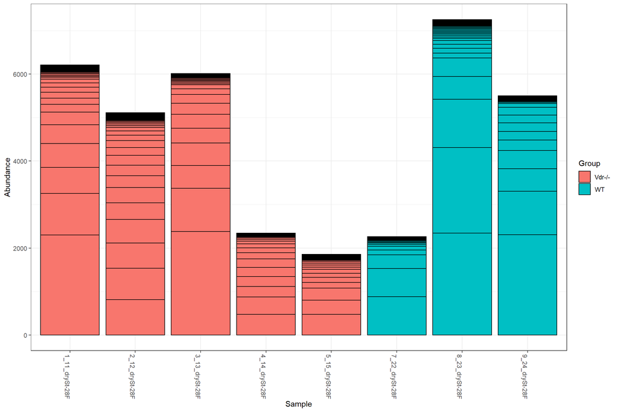

Gráfico de barras de abundancia indicando cual variable es mapeada al parámetro fill.

```r
plot_bar(physeq, fill="Group")
```

El parámetro `facet_grid` es una fórmula que especifica las facetas a mostrar en el gráfico. En el siguiente código, primero encontramos los 5 taxones con más abundancia y después los graficamos añadiendo también el parámetro de `facet_grid`.

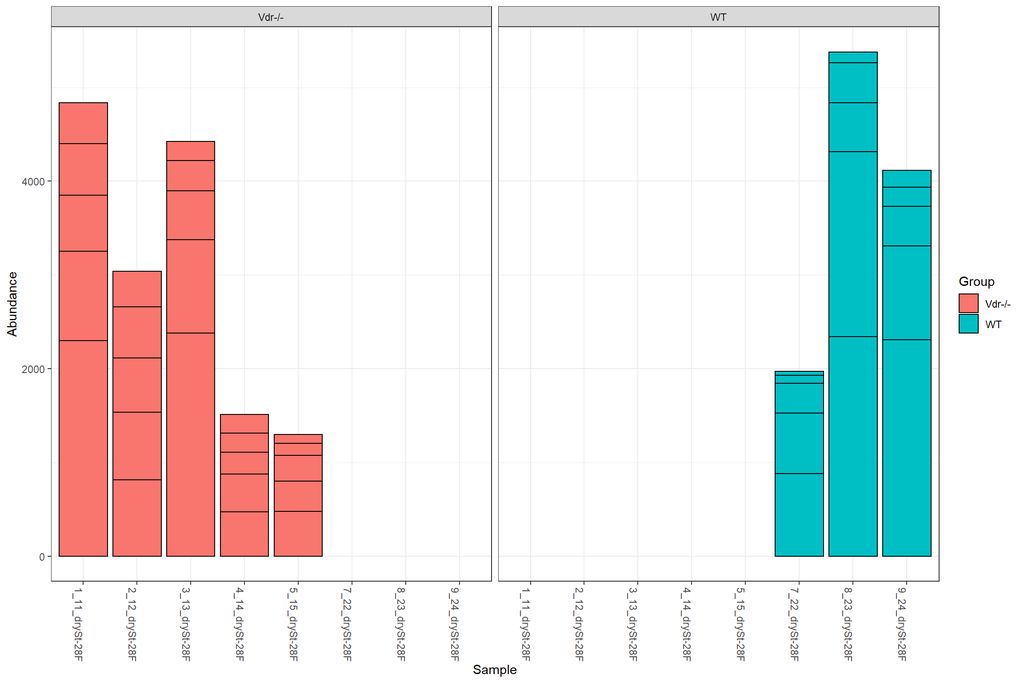

Gráfico de barras de abundancia de los 5 taxones con mayor abundacia.

```r
# Nos da el nombre de los taxones top 5
TopNGenus <- names(sort(taxa_sums(physeq), TRUE)[1:5])
# Generamos un objeto phyloseq con solo los 5 taxa que escogimos
Top5Genus <- prune_taxa(TopNGenus, physeq)
# Graficamos
plot_bar(Top5Genus, fill="Group", facet_grid=~Group)
```

Otra opción que podríamos especificar dentro del parámetro `fill` es `Genus` pero estos datos no cuentan con ese parámetro.

```r
# plot_bar(Top5Genus, fill="Genus", facet_grid=~Group)
```

## Gráfico de mapa de calor

El ordenamiento basado en la ordenación es mucho mejor que el cluster jerárquico para presentar los datos del microbioma. Aquí, nos centramos en ilustrar la función `plot_heatmap()` basada en los métodos de ordenación NMDS y PCA. A continuación se presenta un uso de la función `plot_heatmap()`.

- `plot_heatmap(physeq_object, method = “NMDS”, distance = “bray”, sample.label = NULL, taxa.label = NULL, low = “#000033”, high = “#66CCFF”, na.value = “black”)`.

Se requiere el argumento de datos de entrada “physeq”. Es un objeto de la clase phyloseq (otu_table). Tanto el método como los aumentos de distancia son opcionales. El método de ordenación es el que se utilizará para organizar el mapa de calor. El método de distancia ecológica es una cadena de caracteres para usar en la ordenación. Tanto “sample.label” como “taxa.label” son cadenas de caracteres y opcionales para usar para etiquetar el eje de la muestra (horizontal) y reetiquetar el eje de taxones/especies/OTU (vertical), respectivamente. Los aumentos bajos y altos son cadenas de caracteres y opcionales. Se utilizan para elegir las opciones de color compatibles con R. R entiende más de 600 colores. Puede escribir `colors()` en R para comprobar los nombres.

En los mapas de calor, los valores $0$ son tratados como valores faltantes (NA) y se mapean al color negro. Por lo general, los valores más pequeños se representan por default con el color azul obscuro; mientras que los valores altos con los colores más claros. Para ejemplificar esto, vamos a usar primero solo los cinco taxones con mayor abundancia.

```r
# Nos da el nombre de los taxones top 5
TopNGenus <- names(sort(taxa_sums(physeq), TRUE)[1:5])
# Generamos un objeto phyloseq con solo los 5 taxa que escogimos
Top5Genus <- prune_taxa(TopNGenus, physeq)
# Graficamos
plot_heatmap(Top5Genus)
```

[output not shown]

Vamos a especificar otros parámetros como la distancia y métodos.

```r
# Método NMDS y distancia de Bray-Curtis
p <- plot_heatmap(Top5Genus, "NMDS", "bray")
p
```

[output not shown]

Podemos especificar también los rangos de colores.

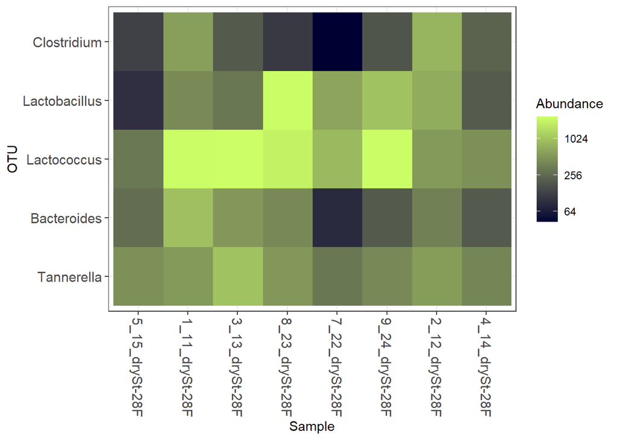

Mapa de calor especificando otras escalas de colores.

```r
plot_heatmap(Top5Genus, "NMDS", "bray", low="#000033", high="#CCFF66")
```

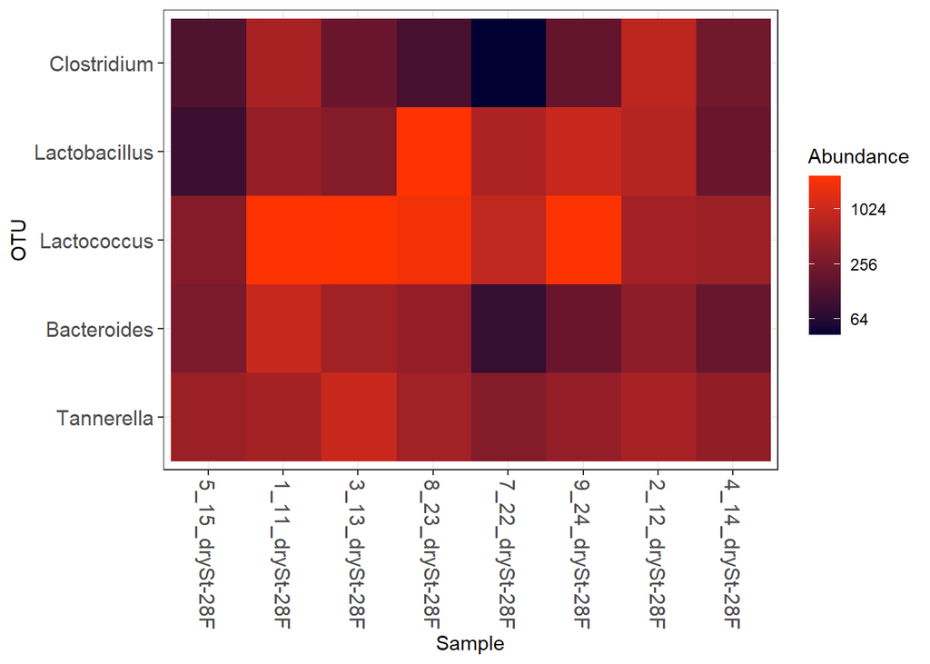

Mapa de calor especificando otras escalas de colores.

```r
plot_heatmap(Top5Genus, "NMDS", "bray", low="#000033", high="#FF3300")
```

```r
plot_heatmap(Top5Genus, "NMDS", "bray", low="#000033", high="#66CCFF")
```

[output not shown]

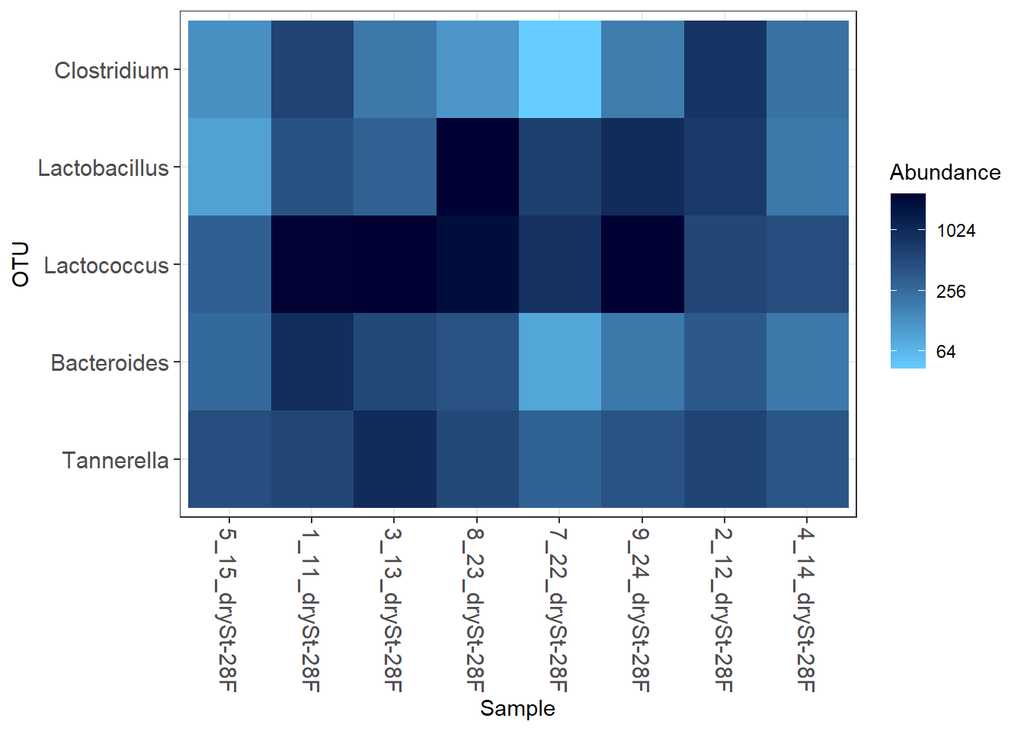

Mapa de calor especificando otras escalas de colores.

```r
plot_heatmap(Top5Genus, "NMDS", "bray", low="#66CCFF", high="#000033", na.value="white")
```

El siguiente mapa de calor es un ejemplo usando PCoA.

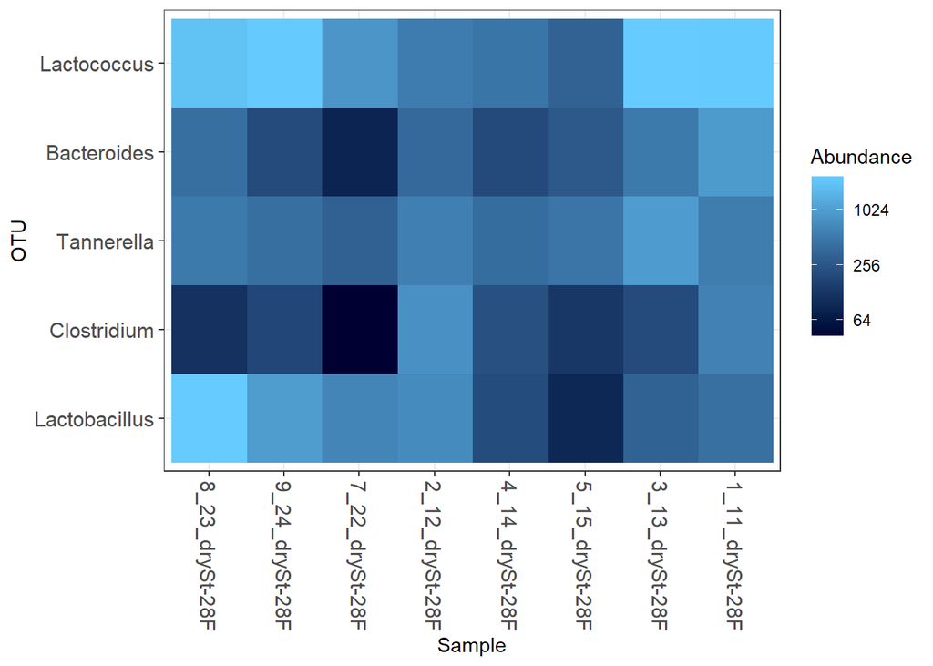

Mapa de calor usando PCoA.

```r
# Método de PCoA y distancia de Bray-Curtis
plot_heatmap(Top5Genus, "PCoA", "bray")
```

## Gráfico de redes

Hay dos funciones en el paquete phyloseq para trazar la red del microbioma usando “ggplot2”: `plot_network()` y `plot_net()`. Si se utiliza la función `plot_network()`, su primer argumento debe ser un objeto `igraph`, y la red en sí debe representarse utilizando el paquete igraph. El objeto red (argumento g) puede ser creado usando la función `make_network()` a través del paquete phyloseq.

La función `plot_net()` es una revisión del rendimiento y de la interfaz de `plot_network()`, su primer/principal argumento es una instancia de la clase phyloseq. Los ejemplos de uso de `plot_network()` y `plot_net()` se dan a continuación:

- `plot_network(g, physeq=NULL, type=“samples”, color=“Group”, shape=“Group”)`
  - g es un objeto de clase igraph necesario creado por la función `make_network()`, o directamente por el paquete igraph.
  - El argumento opcional physeq es un objeto de clase phyloseq en el que se basa g.
  - La opción `Type` indica si el grafo representado en el argumento primario, g, es de muestras o de taxones/OTUs. Por defecto es “samples”.
  - Las opciones *color* y *shape* son opcionales. Se utilizan para el mapeo de color y el mapeo de forma de los puntos.
- `plot_net(physeq, distance = “bray”, type = “samples”, maxdist = 0.7, color = NULL, shape = NULL)`.
  - El argumento requerido physeq, es el objeto de clase phyloseq que se quiere representar como una red.
  - La opción de distancia es un método de distancia o una clase-distancia ya calculada. Por defecto es *bray*.
  - La opción `maxdist` significa el valor máximo de distancia entre dos vértices para conectar con una arista en el grafo. El valor por defecto es $0,7$.

Los siguientes códigos de R crean un grafo basado en igraph, basado en el método de distancia por defecto, *Jaccard* y una distancia máxima entre nodos conectados de $0,8$. El “Group” se utiliza para los mapeos de color y forma para visualizar la estructura de las muestras de ratones *Vdr$-/-$* y *WT*.

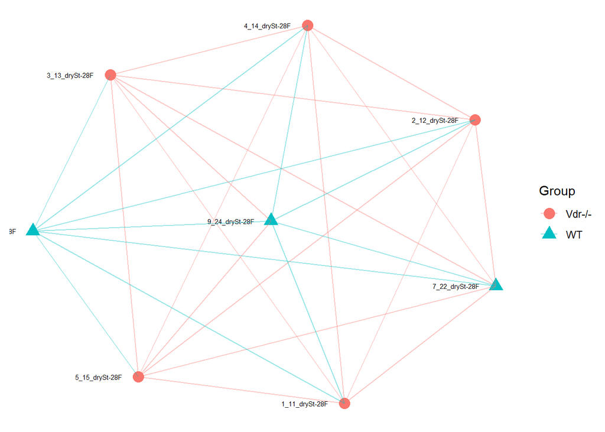

Gráfico usando plot network().

```r
set.seed(123)
library("igraph")
# Hacemos una gráfica a partir de el objeto phyloseq
ig <- make_network(physeq, max.dist=0.8)
# Graficamos
plot_network(ig, physeq, color="Group", shape="Group")
```

En comparación con la función `plot_network()`, la nueva función `plot_net()` no requiere una llamada separada a la función `make_network()`, o un objeto igraph separado. Los códigos siguientes códigos crean una red basada en una distancia máxima entre los nodos conectados de $0,5$. Como estamos interesados en cómo la estructura de las muestras de ratones *Vdr-/-* y *WT* muestras, utilizamos el “Group” para el mapeo de color y el mapeo de forma de los puntos.

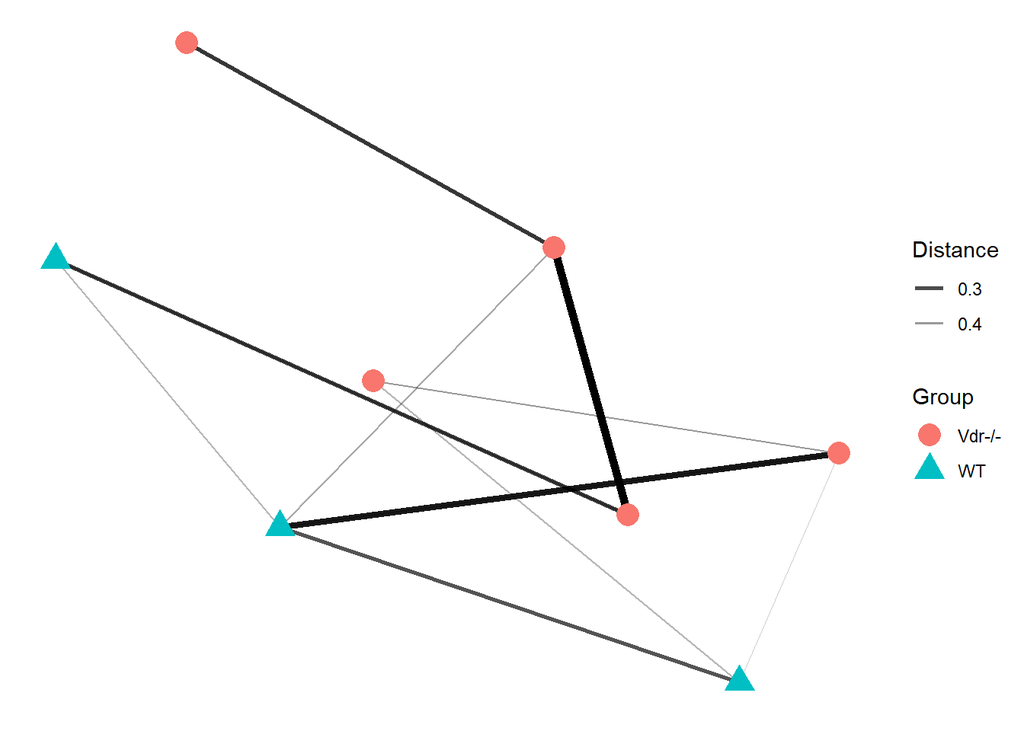

Gráfico de red creado con plot net().

```r
# Graficamos sin necesidad de hacer el objeto anterior
plot_net(physeq, maxdist = 0.5, color = "Group", shape="Group")
```

## Gráfica de árbol filogenético

La función `plot_tree()` del paquete phyloseq pretende facilitar la investigación gráfica del árbol filogenético, así como de los datos de la muestra. Para la secuenciación filogenética de muestras con gran riqueza, el árbol generado por esta función será difícil de leer e interpretar. Una “regla general” propuesta por los autores del paquete phyloseq es utilizar subconjuntos de datos con no más de 200 OTU por parcela. A continuación se muestra un uso de esta función:

- `plot_tree(physeq, method = “sampledodge”, color = NULL, shape = NULL, ladderize = FALSE)`

Los datos de entrada “physeq” son necesarios. Los datos deben ser de la clase phyloseq y contener como *mínimo un componente de árbol filogenético*. Son estos datos los que se quieren trazar y anotar un árbol filogenético. La opción “*method*” es el nombre del método de anotación a utilizar. El método por defecto “*sampledodge*” el cual dibujará puntos junto a las hojas si se observaron individuos de ese taxón, y un punto separado para cada muestra. Los argumentos “*color*” y “*forma*” son opcionales. Proporcionan los nombres de las variables en physeq para mapear el color del punto, y mapear la forma del punto, respectivamente. La opción “ladderize” se utiliza para especificar si el árbol se ordena en forma de escalera o no, es decir reordenar los nodos de acuerdo con la profundidad de sus subárboles antes de trazarlos. Por defecto es FALSE, no se aplica la jerarquización. Cuando es TRUE o “right”, se utiliza la se utiliza la jerarquización. Cuando se establece como “izquierda”, se aplica la escalonación “izquierda”. El conjunto de datos de los fumadores se utiliza para ilustrar el trazado del árbol filogenético. Los datos son del paquete GUniFrac (Charlson et al. 2010; Chen 2012). Primero vamos a cargar este paquete y hagamos que los datos estén disponibles para su uso.

```r
library("GUniFrac")
data(throat.otu.tab)
data(throat.tree)
data(throat.meta)
```

Ahora, necesitamos construir nuestro objeto phyloseq.

```r
# Convertimos los datos en un objeto phyloseq
# Tabla de OTUs
OTU <- otu_table(as.matrix(throat.otu.tab), taxa_are_rows = FALSE)
# Tabla de Sample
SAM <- sample_data(throat.meta)
# Árbol filogenético
TRE <- throat.tree
# Generación del objeto de phyloseq
physeq <- merge_phyloseq(phyloseq(OTU), SAM, TRE)
```

Verificamos cuantos taxones/OTUs tienen nuestros datos.

```r
# Número de taxones
ntaxa(physeq)
```

```
## [1] 856
```

Y seleccionamos solo los primeros $50$.

```r
# Nos quedamos con los primeros 50
physeq <- prune_taxa(taxa_names(physeq)[1:50], physeq)
```

Ahora, graficamos usando como variable en el color el estado de fumador.

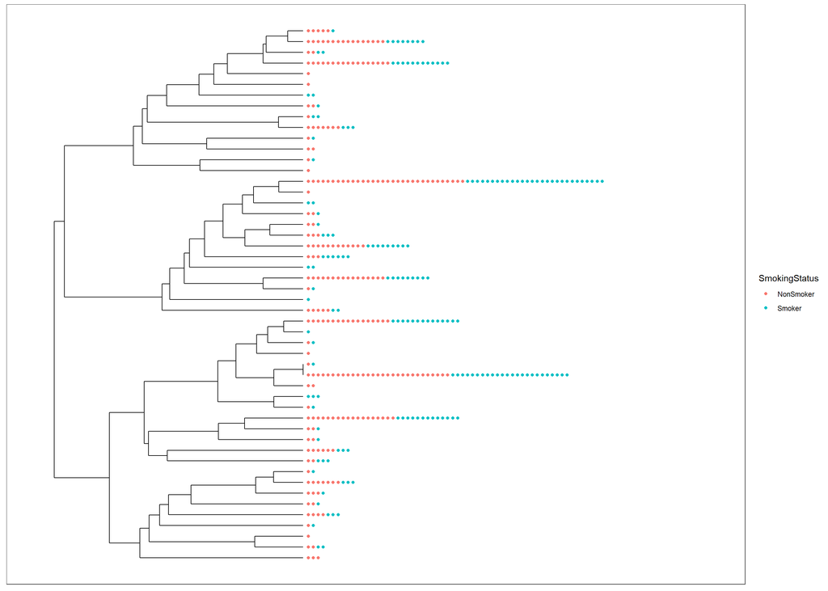

Árbol filogenético usando como color la variable SmokingStatus.

```r
plot_tree(physeq, ladderize = "left", color = "SmokingStatus")
```

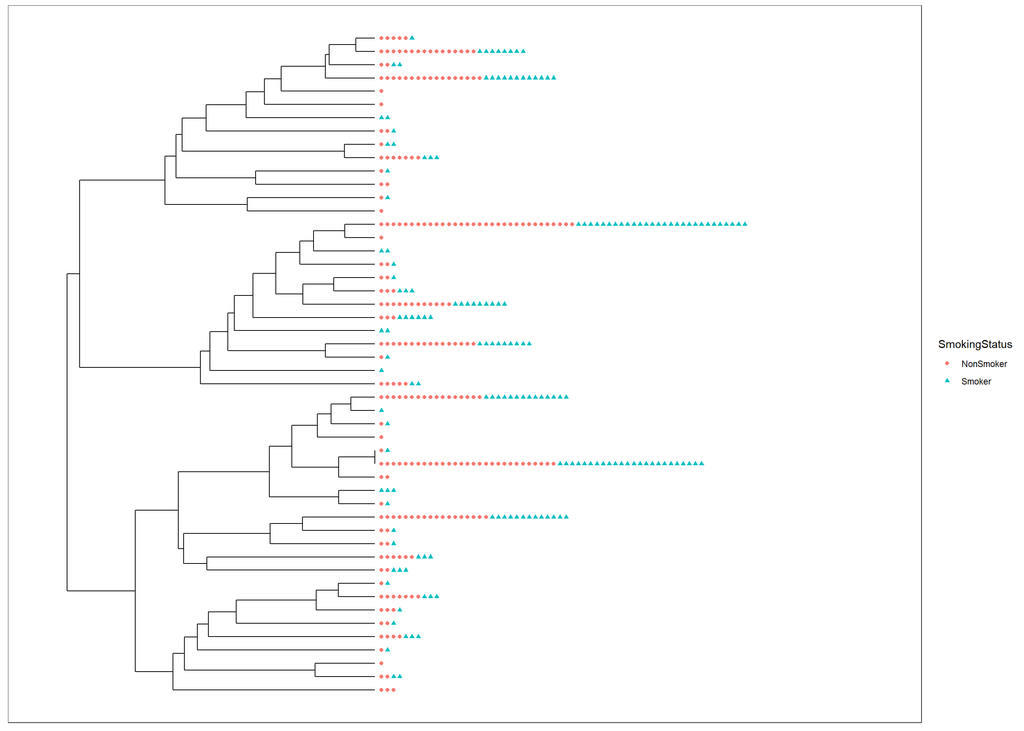

Árbol filogenético usando como color y forma la variable SmokingStatus.

```r
plot_tree(physeq, ladderize = "left", color = "SmokingStatus", shape = "SmokingStatus")
```

Otro tipo de gráfico que se suele ocupar es al mapear los datos a coordenadas polares.

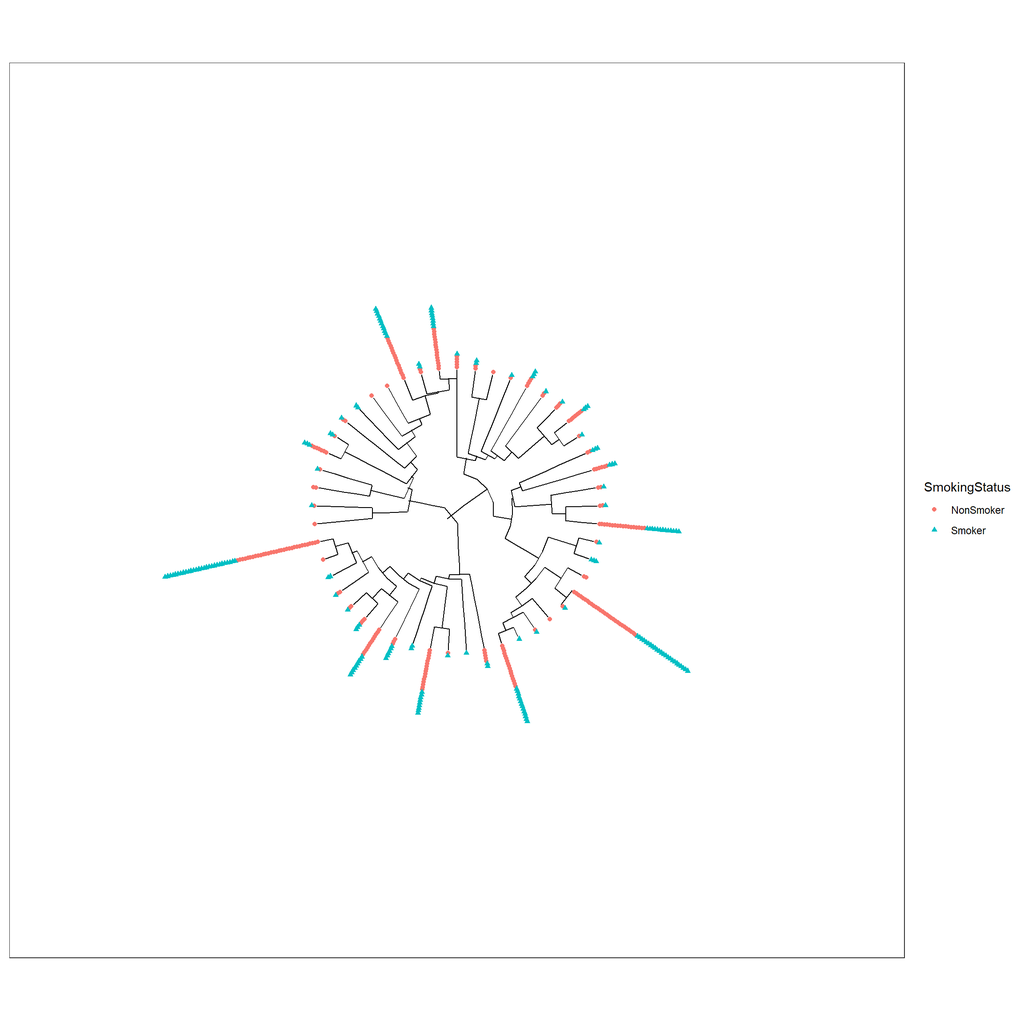

Árbol filogenético con coordenadas polares

```r
plot_tree(physeq, ladderize = "left", color = "SmokingStatus", shape = "SmokingStatus") +
  coord_polar(theta = "y")
```

# Agrupamiento (Clústers)

## Introducción a la agrupación, la distancia y la ordenación

La *agrupación* (o *clasificación*) y la *ordenación* son las dos clases principales de métodos multivariantes que suelen emplear los investigadores del microbioma y los ecologistas de comunidades. Hasta cierto punto, estos dos enfoques son complementarios. El objetivo de la agrupación es clasificar las muestras en clases (quizás jerárquicas) para reducir la complejidad (dimensionalidad) de los datos; puede reducir todas las muestras en una dimensión (eje x).

Sin embargo, los datos con dos o tres dimensiones son más interpretables que los con una dimensión porque la mayoría de los datos comunitarios son continuos. Con la *ordenación* los datos comunitarios pueden reducirse a dos o tres dimensiones. Por lo tanto, la *ordenación* suele ser deseada por los investigadores del microbioma y los ecologistas de comunidades. Se han desarrollado muchos métodos multivariantes basados en la *ordenación* en el estudio del microbioma y la ecología. Cuando se realiza la *agrupación* y la *ordenación*, es necesario que un método de distancia proporcione una medida de distancia.

## Distancias y disimilitudes

Antes de entrar al tema de análisis de clústers es importante introducir los conceptos de distancias y disimilitudes o similitudes.

Una medida de *disimilitud o distancia* entre dos sujetos muy distintos será grande y por el contrario, una medida de *similitud* entre ellos será pequeña.

Existen otras distancias, como la distancia de Gower que puede ser utilizada para estudiar variables aleatorias con entradas cuantitativas y/o cualitativas.

Informalmente, una **similitud** es una medida entre dos objetos de que tanto se parecen. Por lo cual entre más parecidos sean los dos objetos su medida de similitud será más grande. Usualmente toma valores positivos entre 0 y 1.

A diferencia de una distancia o una disimilitud, no existe un análogo para la desigualdad del triángulo para la similitud.

Informalmente, una **disimilitud** entre dos objetos es una medida del grado en el cual dos objetos son diferentes. Como es de esperarse, una disimilitud debe ser baja si se consideran pares de objetos que son similares.

- **Tipo nominal**: La disimilitud más sencilla es
  $$d(x,y) = \left\{
  \begin{matrix}
  0 & \text{ si } x= y \\
  1 & \text{ si } x\neq y
  \end{matrix}
  \right.$$
- **Tipo ordinal**: La disimilitud más sencilla es
  $$d(x,y) = \frac{|x-y|}{n-1}$$
  donde suponemos que hay $n$ datos, y a cada uno de ellos se les ha asignado un valor entero de $0$ a $n-1$.
- **Tipo intervalo**: La disimilitud más sencilla es
  $$d(x,y) = \| x- y\|$$
  donde $\| \cdot \|$ denota la distancia euclidiana usual.

### Distancias y disimilitudes entre datos

En el Cuadro siguiente, se muestra cómo se calculan distancias y disimilitudes entre individuos con datos numéricos, binarios, categóricos y mixtos.

[figure not shown]

tabla de distancias

## Agrupamiento (Clústers)

Existen varias familias de métodos de *agrupamiento* disponibles en la literatura (Legendre y Legendre 2012): **algoritmos secuenciales** o **algoritmos simultáneos**, **aglomerativos** o **divisivos**, **monotéticos** o **politéticos**, **métodos jerárquicos** o **métodos no jerárquicos**, **métodos probabilísticos** frente a **métodos no probabilísticos**. Entre estas categorías, los métodos de *agrupación jerárquica de Ward* y de *partición de k-means* son los más comunes en los estudios sobre el microbioma.

Los métodos jerárquicos aglomerativos, dan origen a un gráfico llamado *dendrogramas*. Estos métodos son iterativos y en cada paso debe recalcularse la matriz de distancias, lo cual para bases de datos muy grandes suele consumir mucho tiempo de cómputo.

En este capítulo se ilustran varios métodos de clustering diferentes, incluyendo:

- *Single linkage agglomerative clustering* o método de la liga sencilla o del vecino más cercano.
- *Complete linkage agglomerative clustering* o método de la liga completa o del vecino más lejano.
- *Average linkage agglomerative clustering* o métdod de la liga promedio.
- *Ward’s minimum variance clustering* o método Ward.

El conjunto de datos de ratones **Vdr$-/-$** con muestras fecales con el que se ha estado trabajando es el que se utilizará para ilustrar el análisis de conglomerados. Aquí, la distancia **Bray-Curtis** se utilizará para ilustrar la clasificación de las muestras. También se aplican otras distancias.

Cargamos el paquete `Vegan`. Primero vamos a *normalizar la tabla de abundancia* utilizando la función `decostand()` y calcular las disimilitudes *Bray-Curtis* entre todos los pares de muestras utilizando la función `vegdist()` del paquete **Vegan**.

```r
library("vegan")
abund_table_norm <- decostand(abund_table, "normalize")
bc_dist <- vegdist(abund_table_norm , method = "bray")
```

### Clustering aglomerativo de la liga sencilla

*“Aglomerar”* significa reunir en un clúster; la agrupación aglomerativa de la liga sencilla también se denomina *clasificación de vecinos más cercanos*. En cada paso, la agrupación combina dos muestras que contienen las distancias más cortas entre pares (o la mayor similitud), es decir, se toma la mínima de todas las posibles distancias entre los objetos que pertenecen a distintos conglomerados:

$$d_{AB}=\min_{i\in A, j\in B}
(d_{ij}).$$

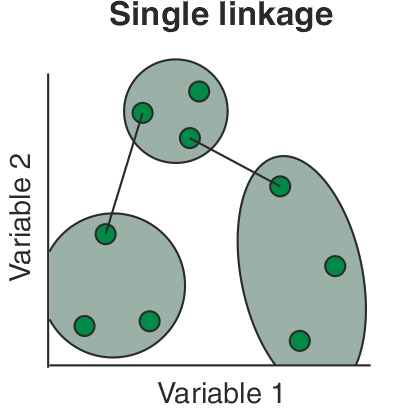

El resultado de la agrupación puede visualizarse como un *dendrograma*. El inconveniente del dendrograma resultante de un clustering de liga sencilla a menudo muestra el encadenamiento de las muestras. Los clústeres formados se ven forzados a unirse debido a que los elementos individuales están cerca unos de otros, mientras que muchos elementos de cada clúster pueden estar muy alejados entre sí. Otro inconveniente relevante del clustering de la liga sencilla es que podría ser difícil de interpretar en términos de particiones de los datos. Es una desventaja real del clustering de la liga sencilla porque estamos interesados en las particiones de los datos. Este método se tiende a desempeñar bien cuando hay grupos de forma elongada, conocidos como tipo cadena.

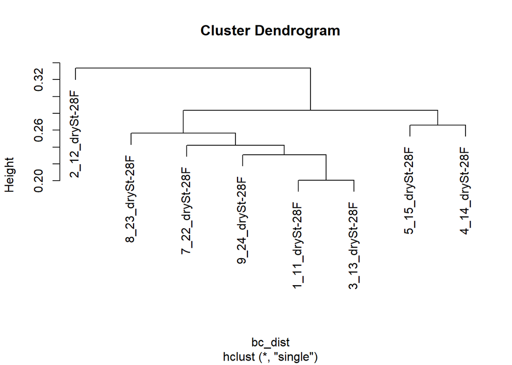

Cluster con el método single.

```r
cluster_single <- hclust (bc_dist, method = 'single')
plot(cluster_single)
```

### Clustering aglomerativo de la liga completa

El clustering de la liga completa también se conoce como *clustering del vecino más lejano*. Permite que que una muestra (o un grupo) se aglomere con otra muestra (o grupo) *sólo a la distancia más lejana entre sí*. Así, todos los miembros de ambos grupos están vinculados.

$$d_{AB}=\max_{i\in A, j\in B}
(d_{ij}).$$

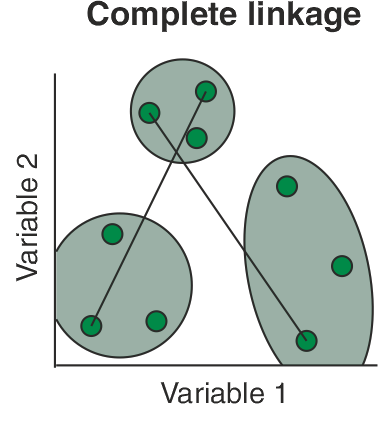

La agrupación de la liga completa evita el inconveniente de encadenar las muestras por el método de la liga simple. El encadenamiento completo tiende a encontrar muchos pequeños grupos separados. Este método se desempeña bien cuando los conglomerados son de forma circular.

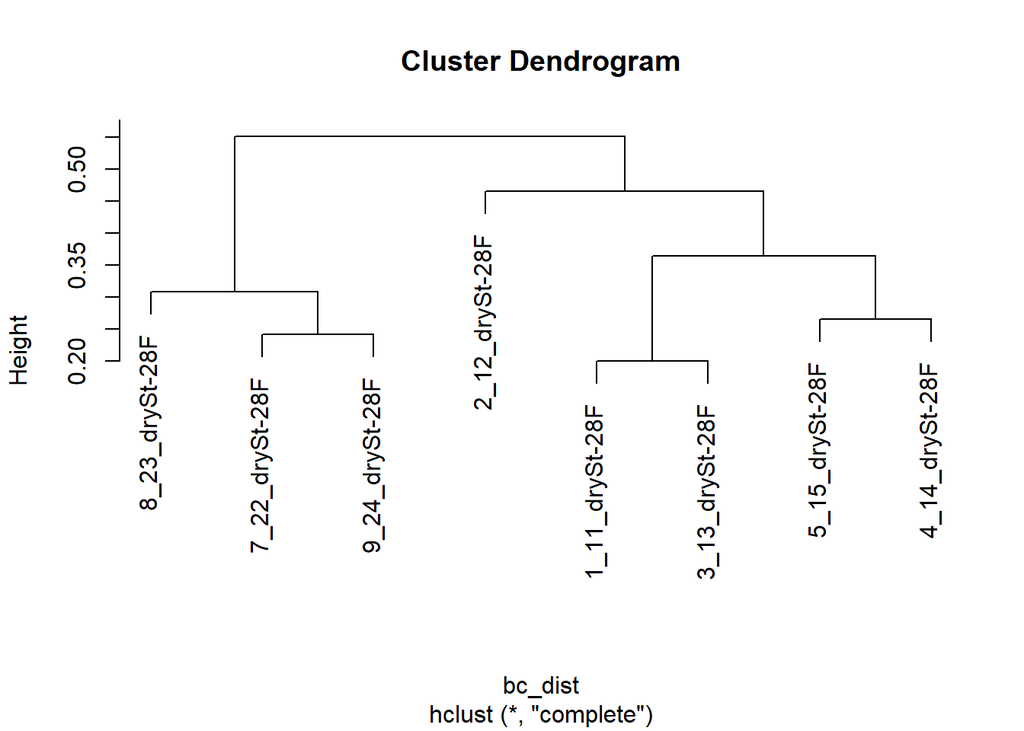

Cluster con el método complete.

```r
cluster_complete <- hclust (bc_dist, method = 'complete')
plot(cluster_complete)
```

### Clustering aglomerativo de la liga promedio

La agrupación de liga promedio permite agrupar una muestra en un clúster en la media de las distancias entre esta muestra y todos los miembros del clúster. Los dos clusters se unen a la *media de las distancias entre todos los miembros de un clúster y todos los miembros del otro*.

$$d_{AB}=\frac{1}{n_An_B} \sum_{i\in A}
\sum_{j\in B} (\ d_{ij}\ ).$$

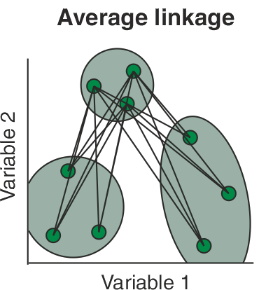

El clúster resultante del dendrograma tiene un aspecto intermedio entre una agrupación de enlace simple y una completa.

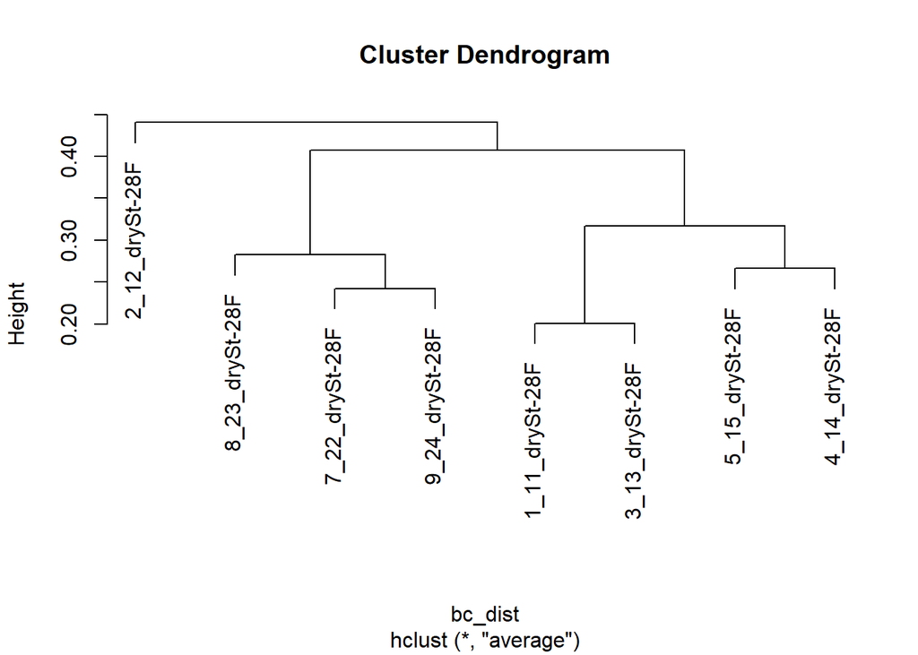

Cluster con el método average.

```r
cluster_average <- hclust (bc_dist, method = 'average')
plot(cluster_average)
```

### Agrupación de varianza mínima de Ward

La agrupación de varianza mínima de Ward (también conocida como agrupación de Ward) presentada originalmente por Ward (1963) se basa en el criterio del *modelo lineal de mínimos cuadrados*. Este método método minimiza las sumas de las distancias al cuadrado (es decir, el error al cuadrado de ANOVA) entre las muestras. Básicamente, considera el análisis de conglomerados como un análisis de la varianza, en lugar de utilizar métricas de distancia o medidas de asociación. Este método es más apropiado para las variables cuantitativas, y no variables binarias. El clustering de Ward se implementa mediante la búsqueda del par de clusters en cada paso que conduce al mínimo incremento de la varianza total dentro del cluster después de la fusión. Este incremento es una distancia cuadrada ponderada entre los centros de los clusters. Aunque las distancias iniciales de los clusters se definen como la distancia euclidiana al cuadrado entre puntos en el clustering de Ward, otros métodos de distancia pueden producir resultados significativos.

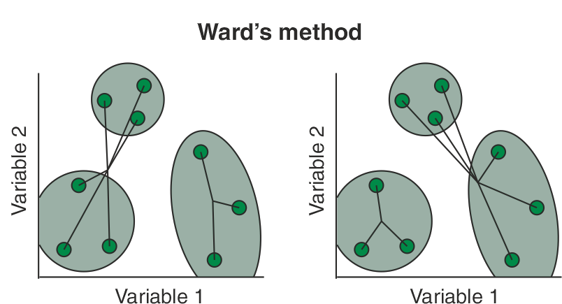

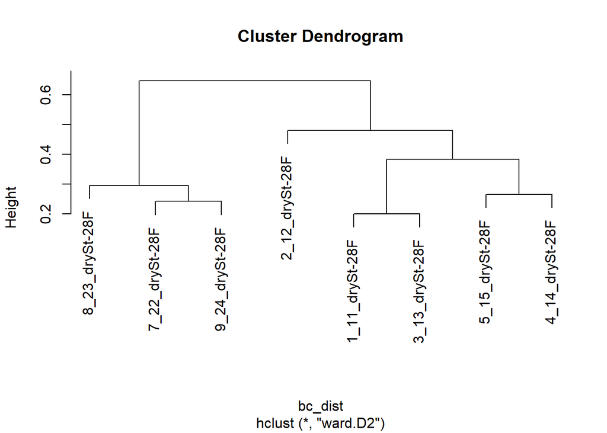

Cluster con el método Ward.

```r
cluster_ward <- hclust (bc_dist, method = 'ward.D2')
plot(cluster_ward)
```

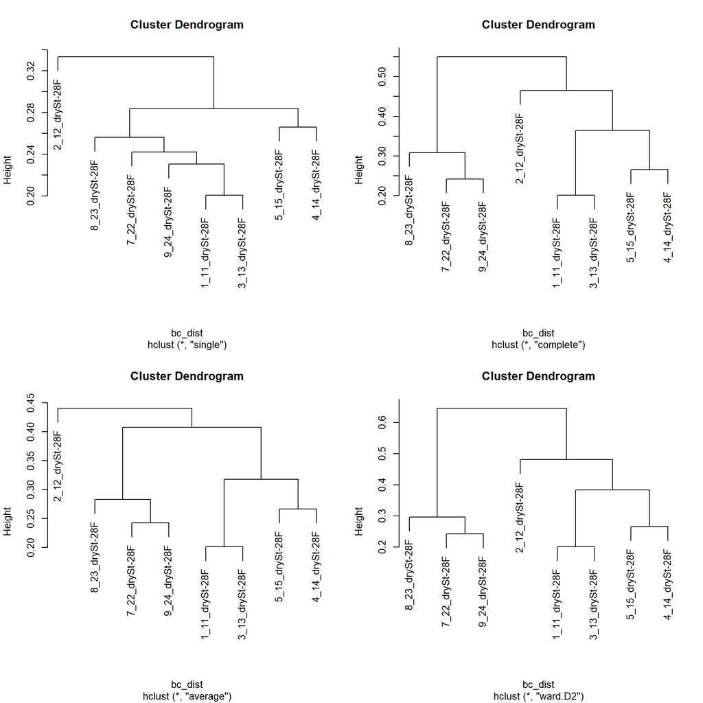

Comparación de los clusters con los 4 métodos.

```r
# Correrlo en consola para visualizarlo mejor
par (mfrow = c(2,2))
plot(cluster_single)
plot(cluster_complete)
plot(cluster_average)
plot(cluster_ward)
```

```r
par (mfrow = c(1,1))
```

La comparación entre estos cuatro dedrogramas muestra que la vinculación completa y Ward generan los mismos clusters de partición y tienen el mejor rendimiento en términos de partición de datos en la dirección de nuestro interés (las muestras 11, 12 13, 14 y 15 son de ratones Vdr$-/-$, y 22, 23 y 24 de ratones de tipo salvaje).

### Mismos gráficos usando el paquete `factoextra`

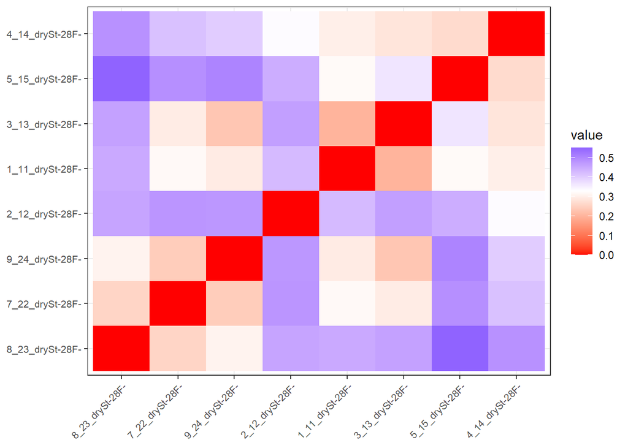

Heatmap de la matriz de distancias

```r
set.seed(12345)
hc_single <- hclust(d=bc_dist, method = "single")
hc_average <- hclust(d=bc_dist, method = "average")
hc_complete <- hclust(d=bc_dist, method = "complete")
hc_ward <- hclust(d=bc_dist, method = "ward.D2")
```

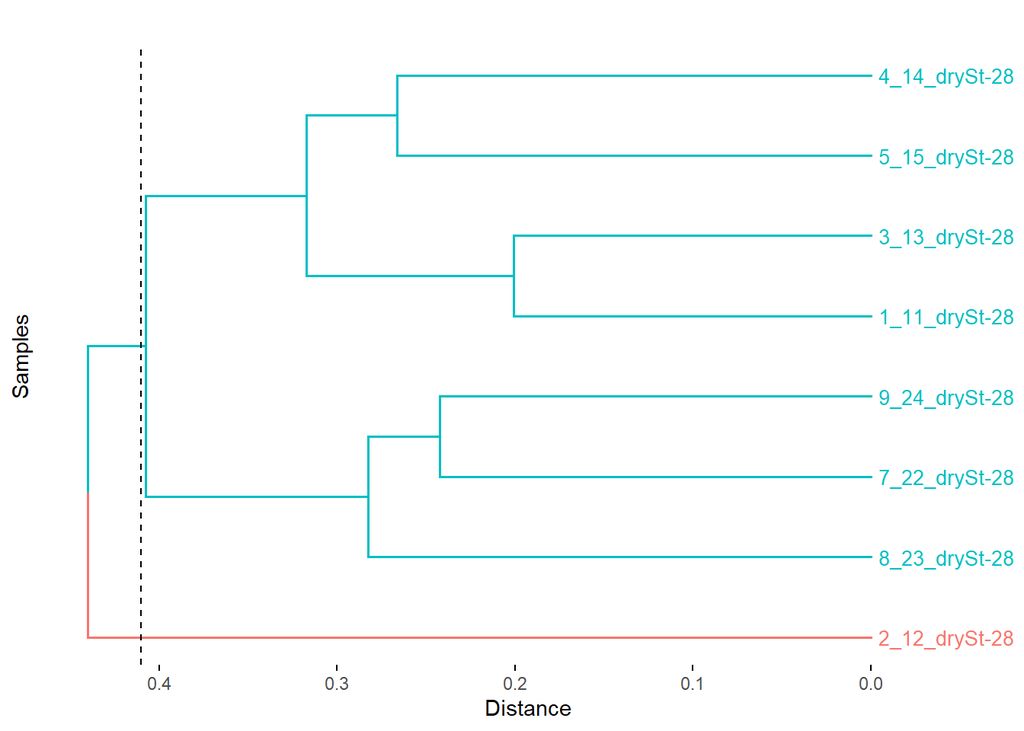

con el método del promedio.

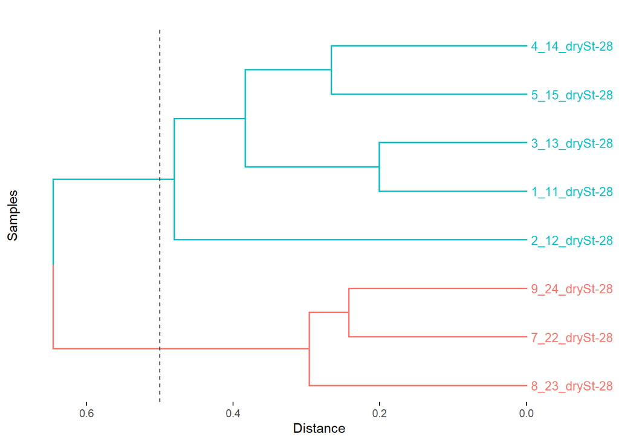

con el método Ward.

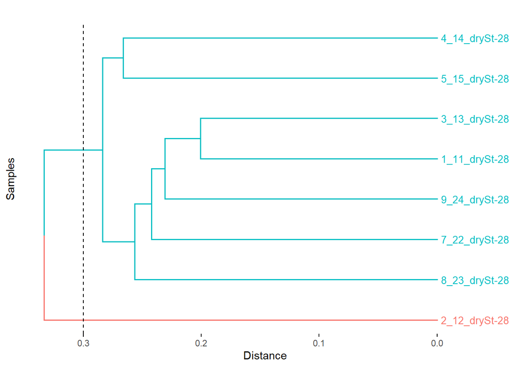

con el método de la liga más sencilla.

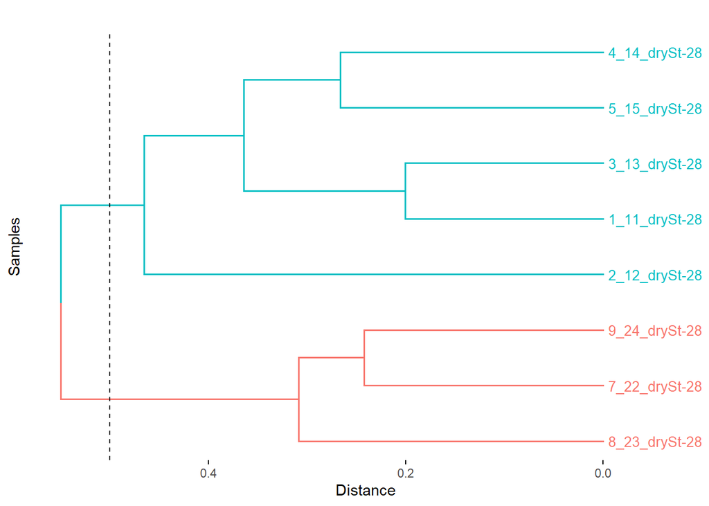

con el método de la liga completa.

# Ordenación

El principal objetivo de la ordenación fue la “exploración” con la introducciónm de un análisis canonico de correspondencia (CCA), la ordenación ha ido más allá de meramente un análisis “exploratorio” y se ha convertido en una prueba de hipótesis.

La estructura de los datos de dos variables suele revelarse mediante un gráfico de dispersión de las muestras. Los datos multivariantes del microbioma son multidimensionales, generalmente tienen más de dos variables. El conjunto de datos del microbioma puede verse como una colección de muestras (sujetos) situadas en un espacio en el que *cada variable o especie (o OTU/taxa) define una dimensión*. Por lo tanto, *hay tantas dimensiones como variables o especies (u OTU/taxa)*. Por ejemplo, en nuestro conjunto de datos fecales de ratón Vdr$-/-$ hay 8 muestras y 248 géneros. Por tanto, la dimensión de los datos es 248. Para un conjunto de datos con n variables, el número de gráficos de dispersión que hay que dibujar sería $n (n - 1)/2$. En nuestro caso, los 248 géneros necesitarán $(248*247)/2 = 30628$ gráficos de dispersión. Un número tan grande de gráficos de dispersión no es informativo para conocer la estructura de los datos; también es tedioso trabajar con ellos.

La ordenación trata principalmente de representar las relaciones entre las muestras y las especies (o OTUs/taxa) lo más fielmente posible en un espacio de baja dimensión (Gauch 1982a, b). Este objetivo es deseable, ya que los datos de la comunidad tienen múltiples dimensiones mezcladas con ruido, las dimensiones bajas pueden representar idealmente y de forma típica interpretaciones importantes e intuitivas de las relaciones especie (o OTUs/taxa)-ambiente. Para un conjunto de datos $n\times p$ que contiene $n$ sujetos y $p$ variables, la estructura de los datos puede revisarse como $n$ sujetos (representados como un grupo de puntos) en el espacio $p-$dimensional.

El **objetivo principal** de la ordenación es representar múltiples muestras (sujetos) en un número reducido de ejes ortogonales (es decir, independientes), donde el número total de ejes es menor o igual al número de muestras (sujetos). La importancia de los ejes de ordenación disminuye por orden. El **primer eje** de una ordenación explica la mayor parte de la variación en el conjunto de datos, seguido por el segundo eje, luego el tercero, y así sucesivamente. Los gráficos de ordenación son especialmente útiles para visualizar la similitud entre muestras (sujetos). Por ejemplo, en el contexto de la diversidad beta, las muestras que están más cerca en el espacio de ordenación tienen conjuntos de especies que son más similares entre sí que las muestras que están más alejadas en el espacio de ordenación.

Los métodos de ordenación incluyen *ordenaciones restringidas* y *no restringidas*, dependiendo de si los ejes de ordenación están limitados por factores ambientales (variables). Como su nombre indica, en la **ordenación restringida**, los ejes de ordenación están están restringidos por factores ambientales: las posiciones de las muestras en la ordenación están limitadas por las variables del entorno. En **la ordenación no restringida**, los ejes de ordenación ejes de ordenación no están limitados por factores ambientales. En otras palabras, la ordenación restringida utiliza directamente las variables ambientales en la construcción de la ordenación, mientras que en la ordenación no restringida los ejes no están limitados por factores ambientales; mientras que en la ordenación sin restricciones, las variables ambientales se introducen en los análisis post hoc.

Desde el punto de vista de la *comprobación de hipótesis*, el análisis de ordenación sin restricciones per se es un método principalmente descriptivo y no implica realmente la comprobación de hipótesis en datos multivariados. Aunque implica la formulación de hipótesis sobre la explicación de los ejes mediante variables ambientales, como la función `envfit()` del paquete `vegan`, la ordenación sin restricciones es sencilla. Analiza una matriz de datos; su objetivo es revelar la estructura principal de los datos en un gráfico a partir de un conjunto reducido de ejes ortogonales. Por el contrario, la ordenación restringida es una ordenación “impulsada por la hipótesis”: un método de comprobación de hipótesis, que pone a prueba directamente la hipótesis sobre la influencia de los factores ambientales en la composición de las especies (o OTU/taxa).

La ordenación restringida está relacionada con los modelos lineales multivariantes, de esta manera con las variables “dependientes” (o la comunidad) en el lado izquierdo como respuestas, las “indenpendientes” (o restricciones) en el lado derecho como factores explicados. Así, la ordenación restringida no es simétrica.

En este apartado se tratan las ordenaciones no restringidas más comunes:

- Análisis de componentes principales (PCA).
- Análisis de coordenadas principales (PCoA).
- Escalamiento multidimensional no métrico (NMDS).
- Análisis de correspondencia (AC).

Y las ordenaciones restringidas:

- Análisis de redundancia redundancia (RDA).
- Análisis de correspondencia restringido (CCA).
- Análisis restringido de coordenadas principales (CAP)*.

## Ordenaciones NO restringidas

### Análisis de componentes principales (PCA)

En cuanto al paquete `vegan`, la *variable ambiental* en nuestro caso es la condición genética (Vdr$-/-$ y WT). **Queremos saber si la deficiencia del gen vdr interpreta la diversidad beta en la composición del género**. Realizamos un PCA para explorar si los cambios en la composición de géneros de las comunidades (diversidades beta) son causados por el factor genético. Con el PCA, las muestras se trazan en base a las abundancias del género A en el eje 1 el género B en el eje 2, el género C en el eje 3, y así sucesivamente hasta que se trazan $n$ muestras en un espacio de muy alta dimensión. Las $n$ muestras crean $(n - 1)$ número de componentes principales (PC):

- PC1: es la primera línea recta que atraviesa el espacio creado por todas estas muestras.
- PC2: es la segunda línea, perpendicular a PC1.

y así la tercera PC3, hasta PC(n - 1). La importancia de las PC disminuye por orden. **PC1 es la PC más importante** y explica la mayor parte de las variaciones entre todas las muestras. La **PC2** explica la segunda mayor parte de las variaciones, y PC3 explica la tercera más, y así sucesivamente la $(n - 1)$ PC explica la menor cantidad de variaciones de las muestras. Varias funciones de R, como `prcomp()` en el paquete preinstalado de estadísticas, `rda()` en el paquete paquete `vegan`, `pca()` en el paquete `labdsv` pueden utilizarse para llevar a cabo el PCA.

En este caso, utilizamos la función `rda()`. Las dos funciones de extensión: `evplot()` (Borcard et al. 2011) y `PCAsignificance()` en el paquete BiodiversityR pueden mejorar los gráficos. La función `evplot()` proporciona métodos visuales para decidir la importancia de los ejes de ordenación mediante el uso de el criterio de *Keiser-Guttman* y el modelo de broken-stick. La función `PCAsignificance()` calcula el modelo de broken-stick para los ejes PCA. Cuando se utiliza la función `rda()` para realizar el PCA, al no especificar la matriz de datos ambientales (es decir, la variable de grupo), la función realiza un ordenación PCA. En el análisis de datos del microbioma, los recuentos de abundancia absoluta no son apropiados porque los valores grandes tendrán una influencia demasiado alta en el análisis. Por lo tanto, **necesitamos estandarizar los datos de lectura de abundancia antes del análisis**. En este caso, utilizamos la función `decostand()` con el método total para estandarizar la lectura.

```r
# Llamamos a nuestra tabla
abund_table=read.csv(paste0(workingDir,"/data/VdrFecalGenusCounts.csv"),row.names=1,check.names=FALSE)
# Transpuesta de la tabla
abund_table<-t(abund_table)
#head(abund_table)
# Tabla de metadatos
meta_table <- data.frame(row.names=rownames(abund_table),
                         t(as.data.frame(strsplit(rownames(abund_table),"_"))))
# Agregamos el factor de grupo
meta_table$Group <- with(meta_table,ifelse(as.factor(X2)%in% c(11,12,13,14,15),
                                           c("Vdr-/-"), c("WT")))
# Estandarizamos la abundancia de los datos
stand_abund_table <- decostand(abund_table, method = "total")
PCA <-rda(stand_abund_table)
PCA
```

```
## Call: rda(X = stand_abund_table)
##
##               Inertia Rank
## Total         0.04082
## Unconstrained 0.04082    7
## Inertia is variance
##
## Eigenvalues for unconstrained axes:
##      PC1      PC2      PC3      PC4      PC5      PC6      PC7
## 0.020288 0.012792 0.003712 0.001730 0.001425 0.000774 0.000098
```

Con el siguiente código podemos pedir los valores de los eigenvalores.

```r
ev <- PCA$CA$eig
```

En lenguaje `vegan`, **“Inertia”** es el término general de **“variación”** en los datos. El total de variación de todo el conjunto de datos es de 0.0408196 en este caso, y el primer eje explica el 49.7017233% de la variación total (0,02029/0,0408 = 0,4973). La **variación total** es la suma de las variaciones de cada género en la matriz analizada. Los siguientes códigos R comprueban la variación total:

```r
# Variación total
sum(apply(stand_abund_table, 2, var))
```

```
## [1] 0.04081957
```

Otra forma de obtener este análisis es llamando la función `summary`.

```r
head(summary(PCA))
```

```
##
## Call:
## rda(X = stand_abund_table)
##
## Partitioning of variance:
##               Inertia Proportion
## Total         0.04082          1
## Unconstrained 0.04082          1
##
## Eigenvalues, and their contribution to the variance
##
## Importance of components:
##                           PC1     PC2      PC3     PC4      PC5       PC6
## Eigenvalue            0.02029 0.01279 0.003712 0.00173 0.001425 0.0007736
## Proportion Explained  0.49702 0.31338 0.090938 0.04239 0.034921 0.0189506
## Cumulative Proportion 0.49702 0.81039 0.901331 0.94372 0.978643 0.9975932
##                             PC7
## Eigenvalue            9.824e-05
## Proportion Explained  2.407e-03
## Cumulative Proportion 1.000e+00
##
## Scaling 2 for species and site scores
## * Species are scaled proportional to eigenvalues
## * Sites are unscaled: weighted dispersion equal on all dimensions
## * General scaling constant of scores:  0.731125
##
##
## Species scores
##
##                                   PC1       PC2        PC3        PC4
## Tannerella                 -0.1460060  0.059004 -0.1581134  0.0263299
## Lactococcus                 0.3347414  0.268815  0.0199084 -0.0094492
## Lactobacillus               0.2884642 -0.241439 -0.0576255  0.0148015
## Lactobacillus::Lactococcus  0.0047630  0.002077 -0.0002720 -0.0008367
## Parasutterella              0.0002188 -0.001427 -0.0000296 -0.0008465
## Helicobacter               -0.0390189  0.005225 -0.0389887 -0.0101868
## ....
##                                   PC5        PC6
## Tannerella                 -0.0074351 -0.0108844
## Lactococcus                 0.0133844 -0.0002257
## Lactobacillus               0.0420286  0.0006774
## Lactobacillus::Lactococcus  0.0037431 -0.0004606
## Parasutterella             -0.0009601  0.0001548
## Helicobacter               -0.0106939 -0.0092049
## ....
##
##
## Site scores (weighted sums of species scores)
##
##                     PC1      PC2       PC3     PC4      PC5      PC6
## 5_15_drySt-28F -0.35858  0.04972 -0.443749 -0.2395 -0.12631 -0.21700
## 1_11_drySt-28F -0.01508  0.25950  0.308436 -0.4460  0.28194  0.14170
## 2_12_drySt-28F -0.28343 -0.36080  0.318538  0.1051  0.10647 -0.28342
## 3_13_drySt-28F  0.02043  0.37303 -0.007325  0.1292 -0.26490  0.07505
## 4_14_drySt-28F -0.24988 -0.01016  0.007908  0.3703  0.03704  0.44259
## 7_22_drySt-28F  0.31464 -0.02094 -0.313787  0.1650  0.47544 -0.09180
## 8_23_drySt-28F  0.28787 -0.42150 -0.065406 -0.2454 -0.26694  0.26212
## 9_24_drySt-28F  0.28403  0.13115  0.195385  0.1613 -0.24274 -0.32924
```

[figure not shown]

Explicación PCA

También podemos obtener cuales variables (`species`) tienen la mayor correlación absoluta al primer y segundo eje:

```r
head(sort(abs(PCA$CA$v[,1]),decreasing = TRUE))
```

```
##   Lactococcus Lactobacillus    Tannerella   Clostridium   Bacteroides
##     0.6494296     0.5596474     0.2832653     0.2751724     0.2046105
##   Allobaculum
##     0.1487113
```

```r
head(sort(abs(PCA$CA$v[,2]),decreasing = TRUE))
```

```
##   Lactococcus Lactobacillus   Allobaculum   Akkermansia   Bacteroides
##     0.6567934     0.5899062     0.3501612     0.1680896     0.1457728
##    Tannerella
##     0.1441641
```

A continuación, vamos a dibujar los diagramas utilizando la función `biplot()`. La opción de visualización “species” es la etiqueta del paquete `vegan` para OTUs/taxa. Por defecto es “sites” (etiqueta para muestras).

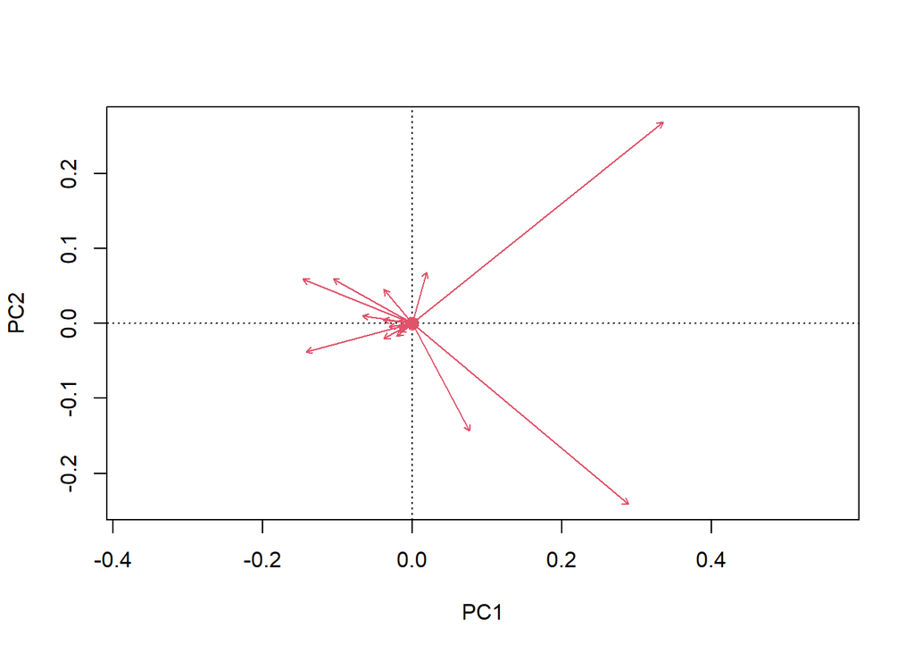

Biplot de las primeras dos componentes principales de los datos de materia fecal de ratones Vdr$-/-$

```r
biplot(PCA, display = 'species')
```

Otros argumentos que uno puede incluir en el biplot son por ejemplo mostrar también los `sites` y agregar etiquetas a los datos, (Ver [vegan](https://cran.r-project.org/web/packages/vegan/vegan.pdf) pag. 37)

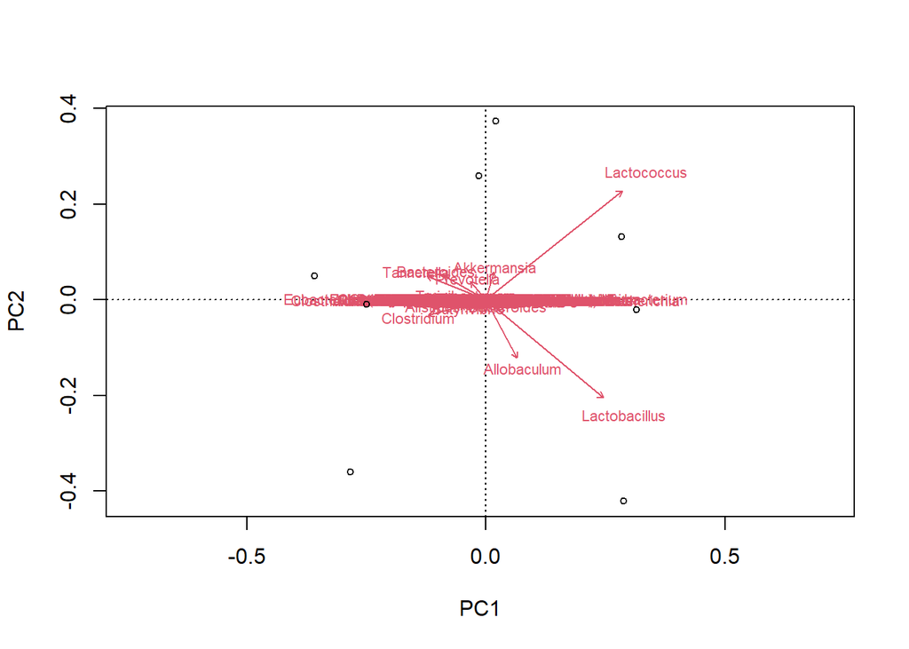

Biplot con etiquetas

```r
#Mismo biplot con etiquetas
biplot(PCA, display = c('sites','species'), type=c("text","points"))
```

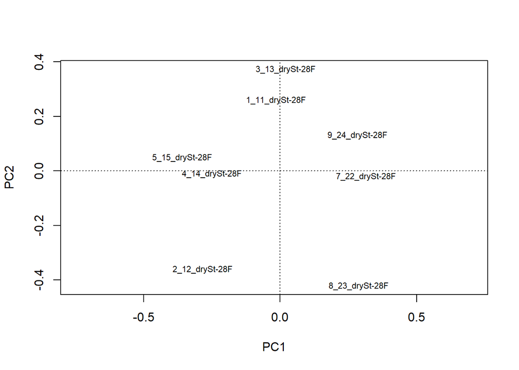

Ordiplot de las primeras dos componentes principales de los datos de materia fecal de ratones Vdr$-/-$ con etiquetas

```r
ordiplot(PCA, display = "sites", type = "text")
```

En los argumentos anteriores, `type="text"` o `t` añade etiquetas de texto a la figura (la configuración por defecto sólo añade puntos). Como alternativa, podemos utilizar la función `cleanplot.pca()` escrita por François Gillet & Daniel Borcard para intentar dibujar los resultados del PCA en dos diagramas y diferenciarlos por su escala. Esta función sirve para dibujar dos biplots (escalado 1 y escalado 2) a partir de un objeto de clase “rda” en PCA o RDA resultado de la función `rda()` de vegan. Primero ejecutamos la función `cleanplot.pca()` como se indica a continuación.

```r
"cleanplot.pca" <- function(res.pca, ax1=1, ax2=2, point=FALSE,
                            ahead=0.07, cex=0.5)
{
  # A function to draw two biplots (scaling 1 and scaling 2) from an object
  # of class "rda" (PCA or RDA result from vegan's rda() function)
  #
  # License: GPL-2
  # Authors: Francois Gillet & Daniel Borcard, 24 August 2012

  require("vegan")

  par(mfrow=c(1,2))
  p <- length(res.pca$CA$eig)

  # Scaling 1: "species" scores scaled to relative eigenvalues
  sit.sc1 <- scores(res.pca, display="wa", scaling=1, choices=c(1:p))
  spe.sc1 <- scores(res.pca, display="sp", scaling=1, choices=c(1:p))
  plot(res.pca, choices=c(ax1, ax2), display=c("wa", "sp"), type="n",
       main="PCA - scaling 1", scaling=1)
  if (point)
  {
    points(sit.sc1[,ax1], sit.sc1[,ax2], pch=20)
    text(res.pca, display="wa", choices=c(ax1, ax2), cex=cex, pos=1, scaling=1)
  }
  else
  {
    text(res.pca, display="wa", choices=c(ax1, ax2), cex=cex, scaling=1)
  }
  text(res.pca, display="sp", choices=c(ax1, ax2), cex=cex, pos=1, col="blue", scaling=1)
  arrows(0, 0, spe.sc1[,ax1], spe.sc1[,ax2], length=ahead, angle=20, col="red")
  pcacircle(res.pca)

  # Scaling 2: site scores scaled to relative eigenvalues
  sit.sc2 <- scores(res.pca, display="wa", choices=c(1:p))
  spe.sc2 <- scores(res.pca, display="sp", choices=c(1:p))
  plot(res.pca, choices=c(ax1,ax2), display=c("wa","sp"), type="n",
       main="PCA - scaling 2")
  if (point) {
    points(sit.sc2[,ax1], sit.sc2[,ax2], pch=20)
    text(res.pca, display="wa", choices=c(ax1 ,ax2), cex=cex, pos=1)
  }
  else
  {
    text(res.pca, display="wa", choices=c(ax1, ax2), cex=cex)
  }
  text(res.pca, display="sp", choices=c(ax1, ax2), cex=cex, pos=1, col="blue")
  arrows(0, 0, spe.sc2[,ax1], spe.sc2[,ax2], length=ahead, angle=20, col="red")
}

"pcacircle" <- function (pca)
{
  # Draws a circle of equilibrium contribution on a PCA plot
  # generated from a vegan analysis.
  # vegan uses special constants for its outputs, hence
  # the 'const' value below.

  eigenv <- pca$CA$eig
  p <- length(eigenv)
  n <- nrow(pca$CA$u)
  tot <- sum(eigenv)
  const <- ((n - 1) * tot)^0.25
  radius <- (2/p)^0.5
  radius <- radius * const
  symbols(0, 0, circles=radius, inches=FALSE, add=TRUE, fg=2)
}
```

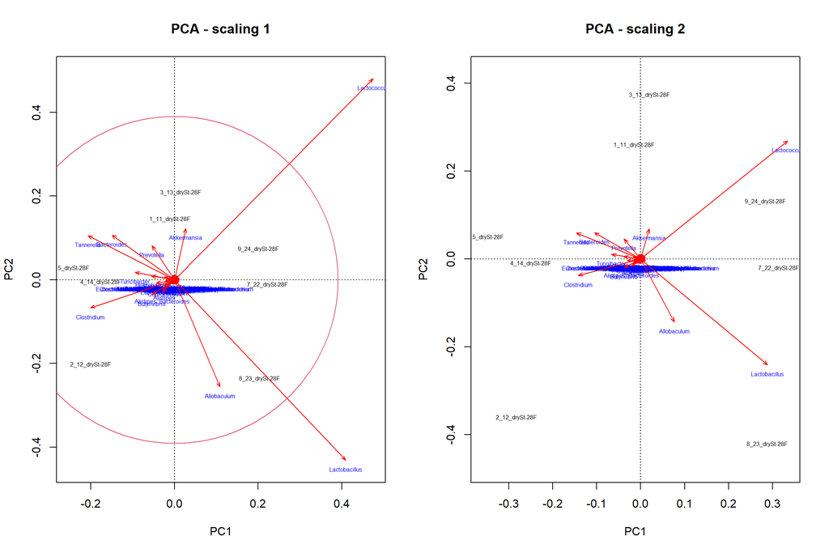

PCA plots de las primeras dos componentes principales de los datos de materia fecal de ratones Vdr$-/-$ usando la función cleant.pca()

```r
cleanplot.pca(PCA)
```

El *“escalado”* es la forma en que los resultados de la ordenación se proyectan en el espacio reducido para su visualización gráfica (Borcard et al. 2011). La función `cleanplot.pca()` genera dos escalas de PCA. El escalado *PCA 1* en la figura de la izquierda es el biplot de distancia que se centra en las distancias entre las muestras. Si está interesado principalmente en interpretar las relaciones entre las muestras, elija el escalado 1. Las características esenciales de Scaling 1 son: Los vectores propios se escalan a la unidad de longitud y las distancias entre las muestras (sujetos) en el biplot son aproximaciones de sus distancias euclidianas en el espacio multidimensional. Sin embargo, los ángulos entre los vectores de las variables (bacterias en este caso) no tienen sentido. El círculo se llama *círculo de contribución de equilibrio*, que representa la contribución de equilibrio de las variables. Para una combinación dada de ejes, las variables con *vectores más largos* que el radio del círculo pueden ser interpretadas con confianza como las *bacterias más importantes*, mientras que las variables con *vectores más cortos* que el radio del círculo de contribución de equilibrio *contribuyen poco* a un espacio reducido dado.

El *PCA 2* de la figura de la derecha es un biplot de correlación. Traza la correlación entre variables (bacterias en este caso). Si su interés principal se centra en *las relaciones entre variables*, elija el escalamiento 2. Las características esenciales del escalamiento 2 son: Cada vector propio se escala a la raíz cuadrada de su valor propio; la longitud del vector se aproxima a la desviación estándar de las variables (bacterias); los ángulos entre variables (bacterias en este caso) reflejan sus correlaciones: el coseno del ángulo aproxima la correlación entre las variables (bacterias); sin embargo, las distancias entre muestras (sujetos) en el biplot no son aproximaciones de sus distancias euclidianas en el espacio multidimensional.

#### Cálculo del PC1

El análisis de componentes principales tiene como objetivo reducir la dimensión y conservar en lo posible la estructura de estos, la cual no depende de los ejes utilizados para las coordenadas. Dadas $n$ observaciones de $p$ variables, se analiza si es posible representar adecuadamente la información con un número menor de variables construidas como combinaciones lineales de las originales. El *primer componente principal* es la combinación lineal de las variables originales que tienen varianza máxima.

Supongamos que tenemos datos en un espacio de $p$ variables en $n$ elementos de una población en una matriz $X$ de tamaño $n\times p$, donde las columnas son las variables y las filas los elementos. Vamos a suponer que hemos restado a cada variable su media, de tal forma que las variables de la matriz $X$ tienen media cero y su matriz de covarianzas está dada por $\frac{1}{n}X'X$. Los valores del primer componente de los $n$ individuos se representará por un vector $\mathbb{z}_1$ que está dado por:
$$\mathbb{z}_1=Xa_{1}.$$

Donde $a_1=(a_{11},\ a_{12},...,\ a_{1p})$. Como las variables originales se supuso tenian media cero, entonces también $\mathbb{z}_1$ tendrá media nula y su varianza sera:
$$\frac{1}{n}\ \mathbb{z}_{1}'\ \mathbb{z}_1 =
\frac{1}{n}\ a_{1}X'Xa_1\ =\ a_1' S a_1.$$
donde $S$ es la matriz de varianzas y covarianzas de las observaciones. Si se elige un $a_1$ que tenga una norma muy grande, entonces la varianza de $\mathbb{z}_1$ podría resultad muy grande también. Entonces es necesario imponer condiciones sobre $a_1$ para acotar el tamaño de la varianza de $\mathbb{z}_1$ y no hacerla muy grande de manera arbitraria. La condición que se impone es:
$$||a_1||=a_1'\cdot a_1=1.$$

Esta restricción se introduce mediante el multiplicador de Lagrange:

$$M\ =\ a_1' S a_1\ -\
\lambda(a_1'a_1\ -\ 1).$$

Después, se maximizará esta expresión derivando con respecto a los componentes de $a_1$ e igualando a $0$:

$$\frac{\partial M}{\partial a_1} =\
2Sa_1 -2\lambda a_1 =0$$

cuya solución es:

$$Sa_1=\lambda a_1$$

entonces $a_1$ es un vector propio de la matriz $S$ y $\lambda$ será su correspondiente valor propio.

Para determinar que valor propio de $S$ es la solución de la ecuación anterior, multiplicamos por $a_1$ a la izquierda:

$$a_1'Sa_1=\lambda a_1'a_1
=\lambda$$

entonces, $\lambda$ es la varianza de $\mathbb{z}_1$. Como esta es la cantidad que queríamos maximizar, entonces $\lambda$ será el valor propio mayor de la matriz $S$ y su vector asociado $a_1$ serán los coeficientes de cada variable de la primera componente.

### Análisis de coordenadas principales (PCoA)

El PCoA también se denomina *escalamiento multidimensional métrico*. PCoA es una técnica de ordenación que permite al usuario elegir prácticamente cualquier métrica de distancia (por ejemplo, *Jaccard*, *Bray-Curtis*, *Euclides*, etc.). Al igual que PCA, PCoA utiliza los valores propios para medir la importancia de un conjunto de ejes ortogonales devueltos. La dimensionalidad de la matriz se reduce determinando cada vector propio y cada valor propio. Las coordenadas principales se obtienen escalando cada vector propio. El PCoA cuando se calcula sobre distancias euclidianas entre las muestras produce los mismos resultados que el PCA calculado sobre matriz de covarianza del mismo conjunto de datos (si se utiliza el escalado 1). Las funciones de R, incluyendo `cmdscale()` en el paquete `vegan` y `pcoa()` en el paquete `ape` pueden realizar el PCoA. Con vegan, los datos de entrada pueden ser calculados por la función `vegdist()` (por defecto es la disimilitud de *Bray-Curtis*), y el diagrama de ordenación puede ser dibujado con la función `ordiplot()`. El diagrama de ordenación también puede ser con la función `biplot.pcoa()` del paquete `ape`. En este caso, utilizamos la función `cmdscale()` y los mismos datos fecales de ratones Vdr$-/-$ para realizar un PCoA. Esta función necesita una matriz de semejanza como datos de entrada. Primero, vamos a calcular la *disimilitud de Bray-Curtis* utilizando la función `vegdist()`.

```r
options(digits=4)
options(width=78, digits=4)
library("vegan")

bc_dist <-vegdist(abund_table, "bray")
```

Índices de disimilitud de Bray-Curtis

|  | 5_15_ | 1_11_ | 2_12_ | 3_13_ | 4_14_ | 7_22_ | 8_23_ | 9_24_dry |
| --- | --- | --- | --- | --- | --- | --- | --- | --- |
| 5_15_drySt-28F | 0.0000 | 0.5873 | 0.5293 | 0.5786 | 0.2765 | 0.4756 | 0.6487 | 0.5984 |
| 1_11_drySt-28F | 0.5873 | 0.0000 | 0.3742 | 0.2041 | 0.4896 | 0.5208 | 0.4084 | 0.2921 |
| 2_12_drySt-28F | 0.5293 | 0.3742 | 0.0000 | 0.4861 | 0.4114 | 0.4955 | 0.5119 | 0.4368 |
| 3_13_drySt-28F | 0.5786 | 0.2041 | 0.4861 | 0.0000 | 0.4645 | 0.5436 | 0.4217 | 0.2362 |
| 4_14_drySt-28F | 0.2765 | 0.4896 | 0.4114 | 0.4645 | 0.0000 | 0.4172 | 0.6220 | 0.5210 |
| 7_22_drySt-28F | 0.4756 | 0.5208 | 0.4955 | 0.5436 | 0.4172 | 0.0000 | 0.5356 | 0.4359 |
| 8_23_drySt-28F | 0.6487 | 0.4084 | 0.5119 | 0.4217 | 0.6220 | 0.5356 | 0.0000 | 0.3105 |
| 9_24_drySt-28F | 0.5984 | 0.2921 | 0.4368 | 0.2362 | 0.5210 | 0.4359 | 0.3105 | 0.0000 |

A continuación, vamos a establecer explícitamente `k = 2` (los valores por defecto para el número de dimensiones a devolver) y `eig = TRUE` (que guarda los valores propios).

```r
PCoA <- cmdscale(bc_dist, eig = TRUE, k = 2)
PCoA
```

```
## $points
##                    [,1]      [,2]
## 5_15_drySt-28F  0.35060  0.007035
## 1_11_drySt-28F -0.17119  0.137244
## 2_12_drySt-28F  0.02928  0.115931
## 3_13_drySt-28F -0.17013  0.126964
## 4_14_drySt-28F  0.27190  0.088394
## 7_22_drySt-28F  0.13943 -0.258936
## 8_23_drySt-28F -0.25091 -0.157891
## 9_24_drySt-28F -0.19898 -0.058740
##
## $eig
## [1]  3.779e-01  1.517e-01  1.170e-01  8.855e-02  2.771e-02  2.167e-02
## [7] -2.515e-17 -4.493e-03
##
## $x
## NULL
##
## $ac
## [1] 0
##
## $GOF
## [1] 0.6713 0.6751
```

La función `cmdscale()` produce una lista de salida. Los primeros **puntos** de salida contienen las coordenadas de cada muestra en cada dimensión reducida. La segunda salida **eig** contiene los valores propios. Las últimas tres salidas pertenecen a otras opciones del análisis que no cubriremos aquí. El siguiente fragmento de códigos R se utiliza para examinar el porcentaje de variación en el conjunto de datos que se explica por los dos primeros ejes del PCoA.

```r
explainedvar1 <- round(PCoA$eig[1] / sum(PCoA$eig), 2) * 100
explainedvar1
```

```
## [1] 48
```

```r
explainedvar2 <- round(PCoA$eig[2] / sum(PCoA$eig), 2) * 100
explainedvar2
```

```
## [1] 19
```

```r
sum_eig <- sum(explainedvar1, explainedvar2)
sum_eig
```

```
## [1] 67
```

El primer eje explica el 48% de las variaciones de los datos, y el segundo el 19%. Por lo tanto, una gran cantidad de variaciones de los datos (un total del 67%) ha sido explicada por estos dos ejes.